# Class 15: Assignment

John Doll

Mar 16 2020

## A more complex example

Let’s now consider a more complex model that also incorporates some *data science* type elements. Each of the 50 United States has been classified into one of 4 census regions:

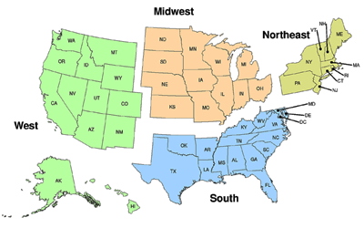

United States Census Regions.

The file `censusRegions.csv` contains a mapping of State abbreviation and its corresponding census region. Consider the following:

```r
states <- read.csv("stateCrimeData.csv")
crimedata <- states %>%
  filter(state != "District of Columbia")

census <- read.csv("censusRegions.csv")
head(census)
```

```
##      Region State
## 1 Northeast    CN
## 2 Northeast    ME
## 3 Northeast    MA
## 4 Northeast    NH
## 5 Northeast    RI
## 6 Northeast    VT
```

```r
names(crimedata)
```

```
##  [1] "state"        "stabbr"       "Pop"          "Murder"       "Rape"
##  [6] "Robbery"      "Assault"      "PropertyCr"   "Burglary"     "Larceny"
## [11] "VehTheft"     "UnEmp"        "HSGrad"       "CollGrad"     "MedianInc"
## [16] "Pop1000_2005" "TotJustice"   "Police"       "Judicial"     "Corrections"
## [21] "NetElectric"  "unleadedgas"
```

```r
census <- census %>%
  rename(stabbr = State)
crimedata <- left_join(crimedata, census, by="stabbr")
unique(crimedata$Region)
```

```
## [1] South     West      Northeast Midwest
## Levels: Midwest Northeast South West
```

- First, we read in the `stateCrimeData.csv` file from the earlier in-class discussion, and remove the District of Columbia from the data set. The resulting file we call `crimedata`.
- Then, we read in the `censusRegions.csv` file and note it contains two variables `Region` and `State` (which is really an abbreviation).
- We then look at the variable names in the crime data and note that the state abbreviation variable is called `stabbr`. Ultimately we want to *join* these two datasets together, so we…
- Rename the `State` variable in `census` to `stabbr`. Now our two datasets contain a **common variable** on which to join cases.
- We then *join* the two datasets. Here we use the `left_join` operation so only observations in the `crimedata` are retained (that is, Washington, DC will be dropped since it is not in the crime data).
- Lastly, we look at the `unique` values of the `Region` variable to demonstrate that our joining appears to be successful.

Now let’s model Burglary rates as a function of census region:

```r
crimefit4 <- lm(Burglary ~ Region, data=crimedata)
summary(crimefit4)
```

```
##
## Call:
## lm(formula = Burglary ~ Region, data = crimedata)
##
## Residuals:
##     Min      1Q  Median      3Q     Max
## -497.49 -122.93   11.26  126.96  448.48
##
## Coefficients:
##                 Estimate Std. Error t value Pr(>|t|)
## (Intercept)       595.68      56.54  10.535 7.55e-14 ***
## RegionNortheast  -130.88      86.37  -1.515 0.136515
## RegionSouth       313.60      74.80   4.193 0.000124 ***
## RegionWest         50.03      78.41   0.638 0.526582
## ---
## Signif. codes:  0 '***' 0.001 '**' 0.01 '*' 0.05 '.' 0.1 ' ' 1
##
## Residual standard error: 195.9 on 46 degrees of freedom
## Multiple R-squared:  0.4347, Adjusted R-squared:  0.3978
## F-statistic: 11.79 on 3 and 46 DF,  p-value: 7.466e-06
```

*ANSWER THE FOLLOWING* with justification based on the output:

**Question 1**. Does this model predict burglary rates?

*Overall, this model does significantly predict burglary rates ($F$-stat of 11.79 on 3 and 46 degrees of freedom, $p$-value=7.466$10^{-6}$).*

**Question 2**. How much of the variability in burglary rates is explained by census region?

**Question 3**. Interpret the `(Intercept)` term in this model.

*The true mean burglary rate for the Midwest Region is 595.68 per 100,000 residents.*

**Question 4**. Interpret the `RegionNortheast` term in this model.

*Being in the Northeast Region is associated with a 130.88 decrease in burglury rates.*

**Question 5**. What do each of the 3 $t$-tests imply?

*Being in the Northeast Region is not a significant predictor for burglary rates ($p$-value of .136).*  
*Being in the South Region is a significant predictor for burglary rates ($p$-value of .000124).*  
*Being in the West Region is not a significant predictor for burglary rates ($p$-value of .526).*